# Week 4 Lab. Confidence Intervals

Craig Enders

Friday October 23

■ data frame name ■ numeric variable ■ categorical variable (factor) ■ raw data file name

# The Data

The data for this lab come from a randomized clinical trial of pharmacological treatments for co-occurring cigarette smoking and heavy drinking. Medications that can address both behaviors at once stand to improve health care delivery for these highly prevalent co-occurring conditions. This superiority trial compared the combination of varenicline and naltrexone against varenicline alone for smoking cessation and drinking reduction among 165 heavy-drinking smokers (Ray, Green, Enders, et al., 2021, *American Journal of Psychiatry*, 178, 818–828).

Participants were randomly assigned to one of two medication arms: varenicline plus naltrexone, or varenicline plus placebo pills. Smoking and drinking were assessed at baseline (week 0) and again at weeks 4 and 8. Two variables are of primary interest.

**Breath carbon monoxide.** Breath (alveolar) carbon monoxide is a measure of carbon monoxide in the lungs. CO levels rise with tobacco inhalation and fall after abstinence, so breath CO is a biomarker of recent smoking behavior that is common in clinical trials. Higher values reflect more frequent smoking.

**Medication arm.** The treatment condition each participant was randomly assigned to.

| Variable | Description | Scale |
| --- | --- | --- |
| `ID` | Participant identifier | 1 to 165 |
| `Condition` | Medication arm | 0 = Varenicline, 1 = Varenicline + Naltrexone |
| `Male` | Respondent sex | 0 = Female, 1 = Male |
| `COWeek0`, `COWeek4`, `COWeek8` | Breath carbon monoxide (ppm) at weeks 0, 4, and 8 | 0 to 46 |
| `QuitCigsWeek4`, `QuitCigsWeek8` | Smoking quit status at weeks 4 and 8 | 0 = No quit, 1 = Quit |
| `DrinksWeek0`, `DrinksWeek4`, `DrinksWeek8` | Drinks consumed in the past week at weeks 0, 4, and 8 | 0 to 35 |
| `CigsWeek0`, `CigsWeek4`, `CigsWeek8` | Cigarettes smoked per day at weeks 0, 4, and 8 | 0 to 51 |

Notice that the categorical variables are entered as numbers, not labels: `Condition`, `Male`, and the two quit-status variables are all coded 0 and 1. In the raw file there is nothing to tell R that these codes are categories rather than quantities, which is why the labels in the table above matter. A later step uses the `factor()` function to attach those labels to the data.

# Preliminaries: Loading Packages

R’s built-in functions handle basic statistics, but the displays in this lab come from four add-on packages. `library()` makes a package’s functions available for the current session; it has to be run each time you open R, and it assumes the package was installed beforehand (see the Week 0 R Package Installation Script).

The one package new this week is Rmisc, which provides `CI()` and `group.CI()` for confidence intervals.

```r
# ggplot2 produces the error bar plot
library(ggplot2)

# Rmisc provides CI() and group.CI() for confidence intervals
library(Rmisc)

# psych provides describe() for descriptive statistics
library(psych)

# summarytools provides dfSummary() for data summaries
library(summarytools)

# rstudioapi talks to RStudio, used here to find the folder that contains this script
library(rstudioapi)
```

# Importing Data

There are two ways to get the data file into R. The document uses the first; the second is shown for reference because it is the one you will use with data files stored on your own computer.

Both methods call `read.csv()` with `stringsAsFactors = TRUE`, the same call used in the assignments. The argument converts any text column to a factor, but this file has none: the categorical variables `Condition`, `Male`, `QuitCigsWeek4`, and `QuitCigsWeek8` are stored as 0/1 codes, so every column, including these, is read as numeric. R will happily compute a mean of `Condition` unless told otherwise. The next section converts those codes to factors by hand.

## Option 1: Read From the Course Website

The data file lives on the course GitHub site. Store the web address in an object, then hand that address to `read.csv()`. Keeping the address in its own object is a small convenience: if the file moves, only one line changes.

```r
# store the web address of the raw data file
filepath <- "https://raw.githubusercontent.com/craigenders/psych250a/main/data/ClinicalTrial.csv"

# read the file at that address into a data frame named ClinicalTrial
ClinicalTrial <- read.csv(filepath, stringsAsFactors = TRUE)
```

## Option 2: Read From the Folder That Contains the Script

When a data file is saved in the same folder as your R script, you can point R at that folder and then refer to the file by name alone. The rstudioapi package asks RStudio for the path of the script you are currently editing; `dirname()` strips the file name to leave the folder, and `setwd()` makes that folder R’s working directory. `getwd()` prints the working directory so you can confirm it landed where you expected. After that, `read.csv()` needs only the file name.

This block is displayed but not run, because a knitted document has no script to locate. Run it from an R script saved next to `ClinicalTrial.csv`. In the lab script the same lines are commented out; remove the leading `#` to use them.

```r
# set the working directory to the folder that contains this script
setwd(dirname(getActiveDocumentContext()$path))

# print the working directory to confirm the location
getwd()

# read ClinicalTrial.csv from the working directory into a data frame named ClinicalTrial
ClinicalTrial <- read.csv("ClinicalTrial.csv", stringsAsFactors = TRUE)
```

# Converting Categorical Variables to Factors

R does not know that `Condition`, `Male`, `QuitCigsWeek4`, and `QuitCigsWeek8` are categorical; it sees four numeric columns of 0s and 1s. Left that way, plotting and summary functions would treat them as continuous variables. The `factor()` function converts a numeric column to a *factor*, R’s term for a categorical variable. The `levels` argument lists the codes in the data, and the `labels` argument gives each code a name; the two are matched in order, so 0 becomes the first label and 1 the second.

The conversion replaces each column in place. Once a column is a factor, re-running `factor()` on it with the same `levels` would produce all `NA` values, because the codes no longer exist, so run this block only once after reading the data.

```r
# convert Condition from 0/1 codes to a factor with descriptive labels
ClinicalTrial$Condition <- factor(ClinicalTrial$Condition,
                                  levels = c(0, 1),
                                  labels = c("Varenicline", "Varenicline + Naltrexone"))

# convert Male from 0/1 codes to a factor with descriptive labels
ClinicalTrial$Male <- factor(ClinicalTrial$Male,
                             levels = c(0, 1),
                             labels = c("Female", "Male"))

# convert QuitCigsWeek4 from 0/1 codes to a factor with descriptive labels
ClinicalTrial$QuitCigsWeek4 <- factor(ClinicalTrial$QuitCigsWeek4,
                                      levels = c(0, 1),
                                      labels = c("No Quit", "Quit"))

# convert QuitCigsWeek8 from 0/1 codes to a factor with descriptive labels
ClinicalTrial$QuitCigsWeek8 <- factor(ClinicalTrial$QuitCigsWeek8,
                                      levels = c(0, 1),
                                      labels = c("No Quit", "Quit"))

# print the first few rows to confirm the labels replaced the codes
head(ClinicalTrial)
```

```
  ID                Condition   Male COWeek0 COWeek4 COWeek8 QuitCigsWeek4 QuitCigsWeek8
1  1 Varenicline + Naltrexone   Male      12       2       3          Quit          Quit
2  2              Varenicline Female      20       0       1          Quit          Quit
3  3 Varenicline + Naltrexone   Male      19       3       1          Quit          Quit
4  4 Varenicline + Naltrexone Female       7       3       4          Quit          Quit
5  5 Varenicline + Naltrexone Female       6       7       0       No Quit          Quit
6  6 Varenicline + Naltrexone   Male      14       5       5          Quit          Quit
  DrinksWeek0 DrinksWeek4 DrinksWeek8 CigsWeek0 CigsWeek4 CigsWeek8
1           3           1           6        16         7         0
2           8           3           3        10         3         0
3           9           8           6         8         0         4
4           9           8           5        11         2         0
5           3           3           0         6         1         3
6           7           0           1        13         7         1
```

# Summarizing Data

Before computing anything, look at the whole data frame at once. `dfSummary()` from the summarytools package produces one row per variable showing its type, a compact summary of its values, a small graph of its distribution, and the number of valid and missing cases. It is the fastest way to confirm that a file read in correctly and to notice anything odd — a variable stored as the wrong type, an impossible value, unexpected missingness — before it contaminates later analyses. In the HTML version of this lab, the table is handed to `print()` with `method = "render"` so that it displays as formatted HTML; that wrapper is not needed in your own documents.

```r
# overview of every variable in the data frame
print(dfSummary(ClinicalTrial), method = "render")
```

Data Frame Summary

ClinicalTrial

**Dimensions**: 165 x 14  
**Duplicates**: 0

| **No** | **Variable** | **Stats / Values** | **Freqs (% of Valid)** | **Graph** | **Valid** | **Missing** |
| --- | --- | --- | --- | --- | --- | --- |
| 1 | ID [integer] | Mean (sd) : 83 (47.8) min ≤ med ≤ max: 1 ≤ 83 ≤ 165 IQR (CV) : 82 (0.6) | 165 distinct values (Integer sequence) |  | 165 (100.0%) | 0 (0.0%) |
| 2 | Condition [factor] | 1. Varenicline 2. Varenicline + Naltrexone | 82 ( 49.7% ) 83 ( 50.3% ) |  | 165 (100.0%) | 0 (0.0%) |
| 3 | Male [factor] | 1. Female 2. Male | 65 ( 39.4% ) 100 ( 60.6% ) |  | 165 (100.0%) | 0 (0.0%) |
| 4 | COWeek0 [integer] | Mean (sd) : 10.6 (6.9) min ≤ med ≤ max: 0 ≤ 9 ≤ 46 IQR (CV) : 8 (0.7) | 30 distinct values |  | 165 (100.0%) | 0 (0.0%) |
| 5 | COWeek4 [integer] | Mean (sd) : 5.5 (5.1) min ≤ med ≤ max: 0 ≤ 4 ≤ 24 IQR (CV) : 6 (0.9) | 21 distinct values |  | 165 (100.0%) | 0 (0.0%) |
| 6 | COWeek8 [integer] | Mean (sd) : 5.5 (6) min ≤ med ≤ max: 0 ≤ 3 ≤ 29 IQR (CV) : 8 (1.1) | 25 distinct values |  | 165 (100.0%) | 0 (0.0%) |
| 7 | QuitCigsWeek4 [factor] | 1. No Quit 2. Quit | 63 ( 38.2% ) 102 ( 61.8% ) |  | 165 (100.0%) | 0 (0.0%) |
| 8 | QuitCigsWeek8 [factor] | 1. No Quit 2. Quit | 59 ( 35.8% ) 106 ( 64.2% ) |  | 165 (100.0%) | 0 (0.0%) |
| 9 | DrinksWeek0 [integer] | Mean (sd) : 6.4 (4.4) min ≤ med ≤ max: 1 ≤ 6 ≤ 35 IQR (CV) : 4 (0.7) | 20 distinct values |  | 165 (100.0%) | 0 (0.0%) |
| 10 | DrinksWeek4 [integer] | Mean (sd) : 3.6 (3) min ≤ med ≤ max: 0 ≤ 3 ≤ 13 IQR (CV) : 4 (0.8) | 14 distinct values |  | 165 (100.0%) | 0 (0.0%) |
| 11 | DrinksWeek8 [integer] | Mean (sd) : 3.2 (2.7) min ≤ med ≤ max: 0 ≤ 3 ≤ 13 IQR (CV) : 4 (0.8) | 14 distinct values |  | 165 (100.0%) | 0 (0.0%) |
| 12 | CigsWeek0 [integer] | Mean (sd) : 14.2 (8.2) min ≤ med ≤ max: 3 ≤ 12 ≤ 51 IQR (CV) : 10 (0.6) | 33 distinct values |  | 165 (100.0%) | 0 (0.0%) |
| 13 | CigsWeek4 [integer] | Mean (sd) : 4.2 (5.7) min ≤ med ≤ max: 0 ≤ 2 ≤ 41 IQR (CV) : 5 (1.4) | 22 distinct values |  | 165 (100.0%) | 0 (0.0%) |
| 14 | CigsWeek8 [integer] | Mean (sd) : 3.2 (4.8) min ≤ med ≤ max: 0 ≤ 2 ≤ 35 IQR (CV) : 4 (1.5) | 18 distinct values |  | 165 (100.0%) | 0 (0.0%) |

Generated by summarytools 1.1.5 ([R](https://www.r-project.org/) version 4.6.1)  
2026-10-16

# Descriptive Statistics

`describe()` from the psych package computes the standard numeric summaries for every variable in a data frame. This week the column to watch is the last one, `se`, the standard error of the mean. The standard error is the standard deviation divided by the square root of the sample size, and it is the ingredient that turns a sample mean into a confidence interval.

```r
# descriptive statistics for every variable in the data frame
describe(ClinicalTrial)
```

```
               vars   n  mean    sd median trimmed   mad min max range  skew kurtosis   se
ID                1 165 83.00 47.78     83   83.00 60.79   1 165   164  0.00    -1.22 3.72
Condition*        2 165  1.50  0.50      2    1.50  0.00   1   2     1 -0.01    -2.01 0.04
Male*             3 165  1.61  0.49      2    1.63  0.00   1   2     1 -0.43    -1.83 0.04
COWeek0           4 165 10.55  6.86      9    9.82  5.93   0  46    46  1.41     3.60 0.53
COWeek4           5 165  5.46  5.10      4    4.69  4.45   0  24    24  1.24     0.96 0.40
COWeek8           6 165  5.53  5.96      3    4.55  2.97   0  29    29  1.75     3.35 0.46
QuitCigsWeek4*    7 165  1.62  0.49      2    1.65  0.00   1   2     1 -0.48    -1.78 0.04
QuitCigsWeek8*    8 165  1.64  0.48      2    1.68  0.00   1   2     1 -0.59    -1.66 0.04
DrinksWeek0       9 165  6.40  4.42      6    5.77  2.97   1  35    34  2.44    10.46 0.34
DrinksWeek4      10 165  3.59  2.98      3    3.30  2.97   0  13    13  0.80     0.30 0.23
DrinksWeek8      11 165  3.23  2.68      3    2.97  2.97   0  13    13  0.89     0.67 0.21
CigsWeek0        12 165 14.22  8.22     12   13.05  5.93   3  51    48  1.59     3.20 0.64
CigsWeek4        13 165  4.18  5.70      2    3.08  2.97   0  41    41  3.01    13.13 0.44
CigsWeek8        14 165  3.16  4.75      2    2.25  2.97   0  35    35  3.44    16.81 0.37
```

For `COWeek8`, the mean is 5.53, the standard deviation is 5.96, and the sample size is 165, so the standard error is 5.96 / √165 = 0.46. That value says how far a sample mean of 165 participants typically lands from the population mean. The confidence interval in the next section is built directly from it.

# 95% Confidence Interval

A confidence interval is a range of plausible values for the population mean. It is centered on the sample mean and extends a fixed number of standard errors in each direction: mean ± *t* × SE, where *t* is the critical value from a *t* distribution with *N* − 1 degrees of freedom. For a 95% interval with 164 degrees of freedom, *t* = 1.97.

`CI()` from the Rmisc package does the arithmetic. It takes a single numeric variable and returns three numbers labeled `upper`, `mean`, and `lower`. The `ci` argument sets the confidence level as a proportion.

```r
# mean and 95% confidence interval for COWeek8
CI(ClinicalTrial$COWeek8, ci = 0.95)
```

```
   upper     mean    lower
6.443238 5.527273 4.611307
```

Check the output against the standard error from the previous section: 5.53 ± 1.97 × 0.46 gives 4.61 and 6.44, matching the `lower` and `upper` values. The interval is the mean plus and minus a little under two standard errors.

Interpreting the interval requires care. Under the “extreme populations” interpretation from lecture, the lower limit of 4.61 is the smallest population mean that could plausibly have produced a sample mean of 5.53, and the upper limit of 6.44 is the largest. Population means outside that range are implausible given this sample. The interval does not say that there is a 95% probability the population mean lies between 4.61 and 6.44; the population mean is a fixed number that is either inside the interval or not. The 95% describes the procedure: if the study were repeated many times and an interval computed each time, 95% of those intervals would contain the population mean.

## Changing the Confidence Level

The `ci` argument accepts any proportion. Raising the confidence level widens the interval, because a larger *t* multiplier is needed to capture more of the sampling distribution; lowering it narrows the interval. The standard error is the same in every case, so the only thing that changes is the multiplier.

```r
# mean and 90% confidence interval for COWeek8
CI(ClinicalTrial$COWeek8, ci = 0.90)
```

```
   upper     mean    lower
6.294637 5.527273 4.759908
```

```r
# mean and 99% confidence interval for COWeek8
CI(ClinicalTrial$COWeek8, ci = 0.99)
```

```
   upper     mean    lower
6.736233 5.527273 4.318313
```

The 90% interval runs from 4.76 to 6.30, the 95% interval from 4.61 to 6.44, and the 99% interval from 4.32 to 6.74. Each step up in confidence buys a wider range of plausible values. There is no free lunch: an interval that is more likely to contain the population mean is necessarily less precise about where it is.

# 95% Confidence Interval by Group

`group.CI()` from the Rmisc package computes the same interval separately for each level of a grouping variable. The formula `COWeek8 ~ Condition` reads “COWeek8 broken down by Condition”: the variable to summarize goes on the left of the tilde and the grouping variable on the right. The `data` argument names the data frame that contains both. The output has one row per group with the upper limit, mean, and lower limit for that group.

```r
# mean and 95% confidence interval for COWeek8 within each Condition group
group.CI(COWeek8 ~ Condition, data = ClinicalTrial, ci = 0.95)
```

```
                 Condition COWeek8.upper COWeek8.mean COWeek8.lower
1              Varenicline      6.096362     5.024390      3.952419
2 Varenicline + Naltrexone      7.521061     6.024096      4.527132
```

The varenicline arm has a mean of 5.02 with an interval from 3.95 to 6.10; the combination arm has a mean of 6.02 with an interval from 4.53 to 7.52. The combination arm’s interval is wider because that group’s standard deviation is larger (6.86 versus 4.88 for the varenicline arm), and the standard error inherits that difference.

The same information is easier to read as a graph. Every ggplot2 graph is built in layers joined by `+`:

- `ggplot(ClinicalTrial, aes(x = Condition, y = COWeek8))` names the data frame and maps the grouping variable to the horizontal axis and the outcome to the vertical axis.
- `stat_summary()` computes a summary of the `y` values within each level of `x` and draws it. `fun.data = mean_cl_normal` asks for the mean and its 95% confidence limits, computed the same way `CI()` computes them. `geom = "pointrange"` draws each group as a dot at the mean with a vertical line spanning the interval.

Changing the outcome or the grouping variable requires editing only the two names inside `aes()`; the rest of the call stays the same.

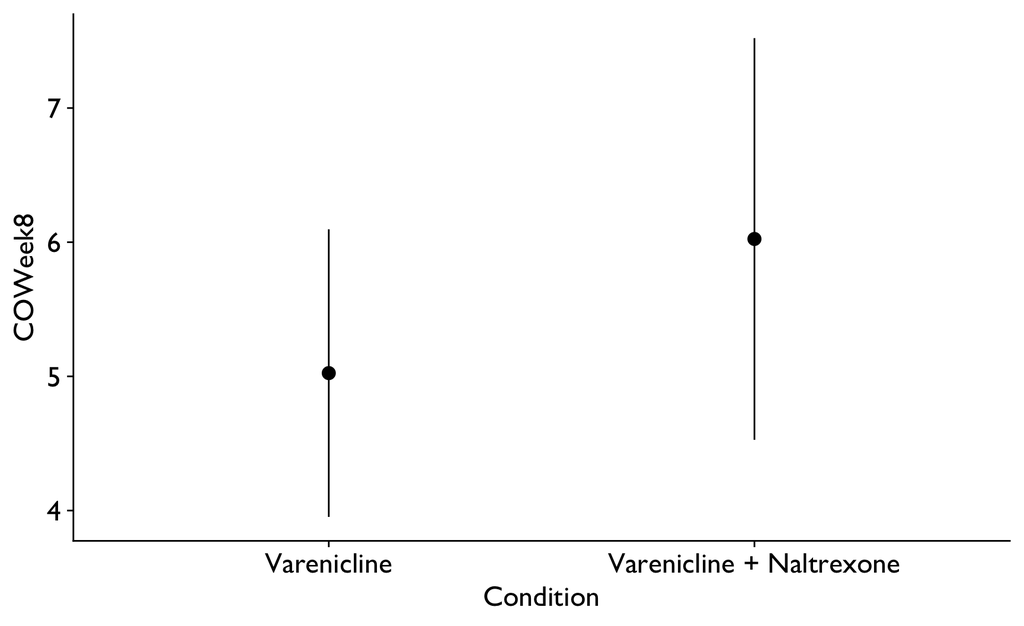

```r
# group means with 95% confidence interval error bars
ggplot(ClinicalTrial, aes(x = Condition, y = COWeek8)) +
  stat_summary(fun.data = mean_cl_normal, geom = "pointrange")
```

The two intervals overlap substantially: the varenicline arm’s upper limit (6.10) sits well above the combination arm’s lower limit (4.53). Cumming and Finch’s (2005) “inference by eye” rule of thumb says that when two independent 95% intervals overlap by more than about half the length of one interval’s arm, the difference between the means is not statistically reliable. Here the overlap is considerably more than that, so the graph gives no evidence that the two medication arms differ in week 8 breath CO. That conclusion is about the means; the groups may still differ in other ways, such as the greater spread in the combination arm that the wider interval reflects.